# EFA Tutorial

Mo’men Mohamed

March 5, 2019

### This is An EFA Project explaining the practice and skills needed

### Notes:

#### that the data used from [statstool](http://statstools.com/) and the tutorial guided by their tutorial

#### For Any Advice Please feel free to contact me at vet.m.mohamed@gmail.com

## Steps

The following is the steps of running **EFA**

1- Testing the Assumptions

2- Specifying the number of factors

3- Choosing the factor math and rotation type

4- Exploring the Adequacy of EFA model

#### First of all lets load all libraries which may need to

```r
library(psych) ; library(GPArotation)
library(bnstruct) ; library(knitr)
```

#### - Now Lets import our data to work with

```r
efadf<-read.csv(file = "3 efa.csv")
head(efadf)
```

```
##   o1 o2 o3 o4 o5 o6 o7 o8 o9 o10 o11 o12 o13 o14 o15 o16 o17 o18 o19 o20
## 1  2  4  3  4  4  4  4  3  4   4   2   2   1   2   3   5   2   4   2   2
## 2  4  4  3  3  3  4  3  3  4   3   3   4   3   3   4   3   4   3   3   3
## 3  5  5  2  5  2  1  1  5  2   2   4   4   2   4   1   4   1   1   2   4
## 4  4  3  4  3  5  4  4  3  4   5   2   2   2   2  NA  NA  NA  NA  NA  NA
## 5  1  1  3  5  4  5  1  1  5   1   5   5   1   5   3   5   1   5   1   5
## 6  5  4  3  5  5  5  4  4  5   5   1   1   1   1   5   1   1   3   1   2
##       condition
## 1 complimentary
## 2    benevolent
## 3 complimentary
## 4 complimentary
## 5       neutral
## 6       neutral
```

```r
efadf<-efadf[,-21]
```

#### here we have to take a look on the data structure and attr.for starting testing the assumptions

## 1- testing the assumption

#### it includes :

##### *Accurecy & Missing Value*

```r
str(efadf)
```

```
## 'data.frame':    99 obs. of  20 variables:
##  $ o1 : int  2 4 5 4 1 5 4 4 4 5 ...
##  $ o2 : int  4 4 5 3 1 4 4 5 5 5 ...
##  $ o3 : int  3 3 2 4 3 3 3 3 3 4 ...
##  $ o4 : int  4 3 5 3 5 5 4 5 4 4 ...
##  $ o5 : int  4 3 2 5 4 5 4 5 5 5 ...
##  $ o6 : int  4 4 1 4 5 5 3 5 5 5 ...
##  $ o7 : int  4 3 1 4 1 4 3 4 3 3 ...
##  $ o8 : int  3 3 5 3 1 4 2 2 3 5 ...
##  $ o9 : int  4 4 2 4 5 5 4 5 5 5 ...
##  $ o10: int  4 3 2 5 1 5 2 5 5 3 ...
##  $ o11: int  2 3 4 2 5 1 3 3 1 1 ...
##  $ o12: int  2 4 4 2 5 1 2 3 2 2 ...
##  $ o13: int  1 3 2 2 1 1 4 2 2 4 ...
##  $ o14: int  2 3 4 2 5 1 2 3 2 2 ...
##  $ o15: int  3 4 1 NA 3 5 3 3 3 2 ...
##  $ o16: int  5 3 4 NA 5 1 2 1 1 2 ...
##  $ o17: int  2 4 1 NA 1 1 3 1 1 2 ...
##  $ o18: int  4 3 1 NA 5 3 3 2 1 2 ...
##  $ o19: int  2 3 2 NA 1 1 3 4 1 2 ...
##  $ o20: int  2 3 4 NA 5 2 2 2 2 2 ...
```

#### as we see here we have a problem with the class of numeric value

```r
for(i in 1:(ncol(efadf))){
  efadf[,i]<-as.numeric(efadf[,i])
}
str(efadf)
```

```
## 'data.frame':    99 obs. of  20 variables:
##  $ o1 : num  2 4 5 4 1 5 4 4 4 5 ...
##  $ o2 : num  4 4 5 3 1 4 4 5 5 5 ...
##  $ o3 : num  3 3 2 4 3 3 3 3 3 4 ...
##  $ o4 : num  4 3 5 3 5 5 4 5 4 4 ...
##  $ o5 : num  4 3 2 5 4 5 4 5 5 5 ...
##  $ o6 : num  4 4 1 4 5 5 3 5 5 5 ...
##  $ o7 : num  4 3 1 4 1 4 3 4 3 3 ...
##  $ o8 : num  3 3 5 3 1 4 2 2 3 5 ...
##  $ o9 : num  4 4 2 4 5 5 4 5 5 5 ...
##  $ o10: num  4 3 2 5 1 5 2 5 5 3 ...
##  $ o11: num  2 3 4 2 5 1 3 3 1 1 ...
##  $ o12: num  2 4 4 2 5 1 2 3 2 2 ...
##  $ o13: num  1 3 2 2 1 1 4 2 2 4 ...
##  $ o14: num  2 3 4 2 5 1 2 3 2 2 ...
##  $ o15: num  3 4 1 NA 3 5 3 3 3 2 ...
##  $ o16: num  5 3 4 NA 5 1 2 1 1 2 ...
##  $ o17: num  2 4 1 NA 1 1 3 1 1 2 ...
##  $ o18: num  4 3 1 NA 5 3 3 2 1 2 ...
##  $ o19: num  2 3 2 NA 1 1 3 4 1 2 ...
##  $ o20: num  2 3 4 NA 5 2 2 2 2 2 ...
```

#### Now lets look at the summary of the data

```r
desc<-apply(efadf,2,function(x){
  (
    round(c(
    min=min(x,na.rm = T),
    max=max(x,na.rm = T),
    mean=mean(x,na.rm = T),
    na=sum(is.na(x))/nrow(efadf)
    ),2)
  )
})

print(desc)
```

```
##        o1   o2   o3   o4   o5   o6   o7   o8   o9  o10  o11  o12  o13  o14
## min  1.00 1.00 1.00 1.00 2.00 1.00 1.00 1.00 1.00 1.00 1.00 1.00 1.00 1.00
## max  5.00 5.00 5.00 5.00 5.00 5.00 5.00 5.00 5.00 5.00 5.00 5.00 5.00 5.00
## mean 3.68 3.96 2.96 3.75 4.24 4.23 3.69 3.56 4.26 3.44 2.47 2.32 2.60 2.78
## na   0.01 0.00 0.00 0.00 0.00 0.02 0.02 0.02 0.02 0.02 0.02 0.02 0.03 0.01
##       o15  o16  o17  o18  o19  o20
## min  1.00 1.00 1.00 1.00 1.00 1.00
## max  5.00 5.00 5.00 5.00 5.00 5.00
## mean 3.15 2.76 2.13 2.72 2.64 2.54
## na   0.02 0.02 0.02 0.03 0.02 0.04
```

#### is there are any item has missing more than 5% ?

```r
any(desc["na",]>.05)
```

```
## [1] FALSE
```

#### great there is no item with more than 5% missing value

#### now test the missing for each individual

```r
ind.desc<-apply(efadf,1,function(x){
  round(c(sum(is.na(x))/ncol(efadf)),2)
})

any(ind.desc>.05)
```

```
## [1] TRUE
```

```r
which(ind.desc>.05)
```

```
## [1]  4 39 68 99
```

```r
ind.desc[which(ind.desc>.05)]
```

```
## [1] 0.30 0.45 0.35 0.40
```

#### woow it is so high percent

#### we will delete these members from the data

```r
efadf<-efadf[-which(ind.desc>.05),]
```

#### Now we have to impute the missing value

```r
efadf<-knn.impute(as.matrix(efadf),k = 5)%>%data.frame()
```

#### finally lets reverse the reversed items !!

```r
key<-rep(1,ncol(efadf))

key[c(1,2,11,13,15,17,19,20)]<-key[c(1,2,11,13,15,17,19,20)]*-1

efadf<-reverse.code(keys = key,items = efadf)
```

#### congrats: we finished this part **Acurecy and missing**

Now I am going to test some assumption related to factor analysis like:

1- **Additivity**

2- **enough correlation between items**

3- **adequacy of sample**

```r
#Additivity

corr<-cor(efadf,method = "p")

apply(corr,2,function(x){
        any(x<1&x>=abs(.9))
})
```

```
##   o1-   o2-    o3    o4    o5    o6    o7    o8    o9   o10  o11-   o12
## FALSE FALSE FALSE FALSE FALSE FALSE FALSE FALSE FALSE FALSE FALSE FALSE
##  o13-   o14  o15-   o16  o17-   o18  o19-  o20-
## FALSE FALSE FALSE FALSE FALSE FALSE FALSE FALSE
```

```r
#Ok !! there is no additivity

#Now test the enough correlation using correlation bartelett test

cortest.bartlett(efadf)
```

```
## $chisq
## [1] 870.0704
##
## $p.value
## [1] 1.435168e-87
##
## $df
## [1] 190
```

```r
#significant result indicate enough correlation

#Finally KMO test for sample size adequacy

KMO(efadf)
```

```
## Kaiser-Meyer-Olkin factor adequacy
## Call: KMO(r = efadf)
## Overall MSA =  0.81
## MSA for each item =
##  o1-  o2-   o3   o4   o5   o6   o7   o8   o9  o10 o11-  o12 o13-  o14 o15-
## 0.79 0.81 0.43 0.69 0.84 0.86 0.60 0.76 0.85 0.88 0.87 0.84 0.82 0.91 0.45
##  o16 o17-  o18 o19- o20-
## 0.86 0.87 0.81 0.75 0.94
```

```r
#here we can see that the data roughly adequate as it is >.8
```

Now it s the time to dive more in EFA

## 2- taking decision about the number of factors

by following the next method

1- **Parallel test**

2- **Kaiser criterion**

3- **scree plot**

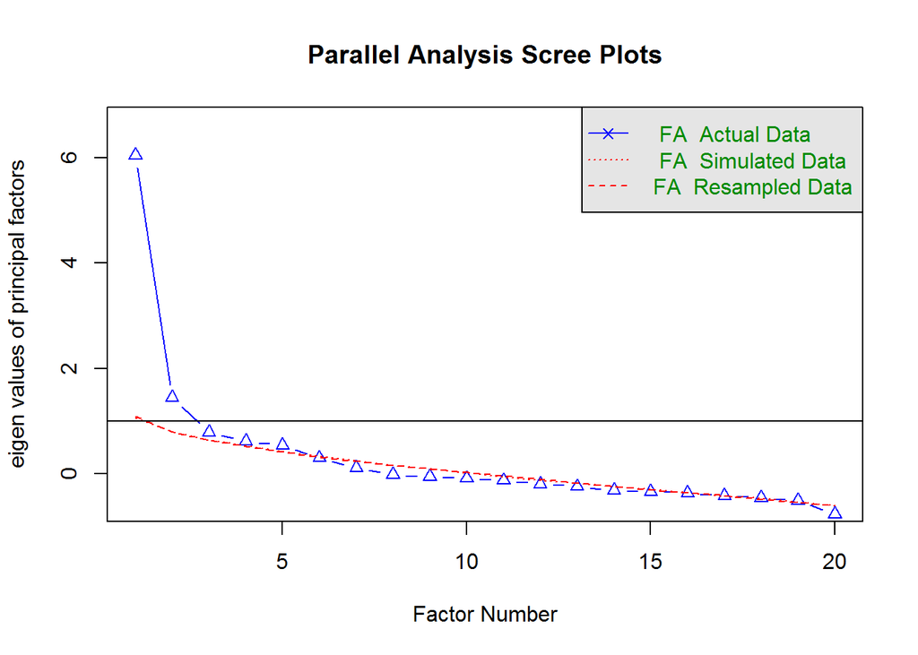

```
## Parallel analysis suggests that the number of factors =  5  and the number of components =  NA
```

```r
nf<-fa.parallel(x = efadf,fa = "fa")#suggestion of parallel test is 5 factors
```

```r
sum(nf$fa.values>.7) #Kaiser criterion suggest 3 factors
```

```
## [1] 3
```

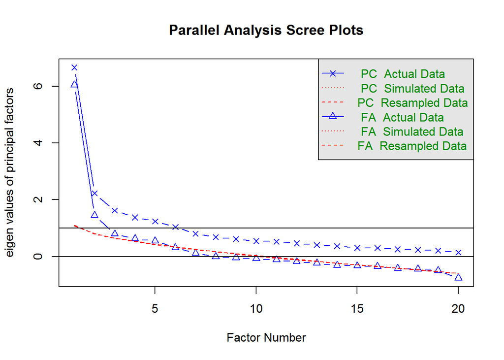

```r
plot(nf) #scree plot suggest 2-3 factor
```

#### lets try 3 factors and look at the adequacy of the model

```r
efafit<-fa(efadf,nfactors = 3,rotate = "oblimin")
print(efafit)
```

```
## Factor Analysis using method =  minres
## Call: fa(r = efadf, nfactors = 3, rotate = "oblimin")
## Standardized loadings (pattern matrix) based upon correlation matrix
##        MR3   MR1   MR2   h2   u2 com
## o1-   0.13  0.88 -0.01 0.69 0.31 1.0
## o2-  -0.12  0.52  0.10 0.34 0.66 1.2
## o3    0.06  0.06  0.83 0.67 0.33 1.0
## o4    0.43  0.07 -0.09 0.17 0.83 1.1
## o5    0.68 -0.01  0.03 0.47 0.53 1.0
## o6    0.65  0.08 -0.05 0.39 0.61 1.0
## o7    0.31 -0.09 -0.04 0.13 0.87 1.2
## o8    0.36 -0.14  0.17 0.23 0.77 1.8
## o9    0.64 -0.04  0.19 0.47 0.53 1.2
## o10   0.54 -0.16 -0.03 0.40 0.60 1.2
## o11-  0.53 -0.36  0.05 0.60 0.40 1.8
## o12  -0.04  0.82  0.04 0.69 0.31 1.0
## o13-  0.66  0.11 -0.04 0.38 0.62 1.1
## o14  -0.17  0.69  0.00 0.63 0.37 1.1
## o15- -0.05 -0.05  0.83 0.71 0.29 1.0
## o16  -0.23  0.57  0.11 0.50 0.50 1.4
## o17-  0.52 -0.18 -0.04 0.39 0.61 1.2
## o18   0.02  0.65 -0.24 0.52 0.48 1.3
## o19-  0.64  0.08 -0.04 0.37 0.63 1.0
## o20-  0.44 -0.29 -0.06 0.40 0.60 1.8
##
##                        MR3  MR1  MR2
## SS loadings           4.01 3.58 1.56
## Proportion Var        0.20 0.18 0.08
## Cumulative Var        0.20 0.38 0.46
## Proportion Explained  0.44 0.39 0.17
## Cumulative Proportion 0.44 0.83 1.00
##
##  With factor correlations of
##       MR3   MR1   MR2
## MR3  1.00 -0.50 -0.03
## MR1 -0.50  1.00 -0.15
## MR2 -0.03 -0.15  1.00
##
## Mean item complexity =  1.2
## Test of the hypothesis that 3 factors are sufficient.
##
## The degrees of freedom for the null model are  190  and the objective function was  10.06 with Chi Square of  870.07
## The degrees of freedom for the model are 133  and the objective function was  2.57
##
## The root mean square of the residuals (RMSR) is  0.07
## The df corrected root mean square of the residuals is  0.08
##
## The harmonic number of observations is  95 with the empirical chi square  163.95  with prob <  0.035
## The total number of observations was  95  with Likelihood Chi Square =  217.21  with prob <  5.6e-06
##
## Tucker Lewis Index of factoring reliability =  0.818
## RMSEA index =  0.093  and the 90 % confidence intervals are  0.062 0.101
## BIC =  -388.46
## Fit based upon off diagonal values = 0.96
## Measures of factor score adequacy
##                                                    MR3  MR1  MR2
## Correlation of (regression) scores with factors   0.93 0.95 0.91
## Multiple R square of scores with factors          0.87 0.90 0.83
## Minimum correlation of possible factor scores     0.74 0.80 0.66
```

```r
#extracting the fit measure

fitm<-c(RMS=efafit$rms,
RMSEA=efafit$RMSEA,
TLI=efafit$TLI,
CFI=(
        1-(efafit$STATISTIC-efafit$dof)/(efafit$null.chisq-efafit$null.dof)
))
print(fitm)
```

```
##              RMS      RMSEA.RMSEA      RMSEA.lower      RMSEA.upper
##       0.06739189       0.09321294       0.06178499       0.10141980
## RMSEA.confidence              TLI              CFI
##       0.90000000       0.81772318       0.87618059
```

#### the model here is poor but lets take a look on the loading and drawing the diagram

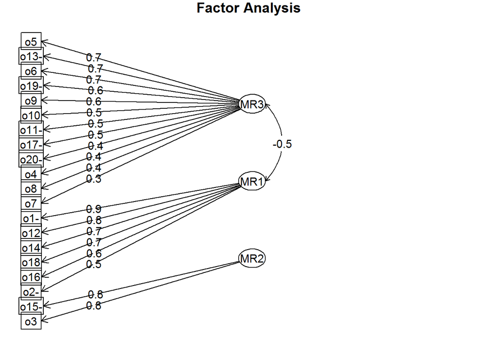

```r
fa.diagram(efafit)
```

```r
efafit$loadings
```

```
##
## Loadings:
##      MR3    MR1    MR2
## o1-   0.126  0.882
## o2-  -0.117  0.523  0.104
## o3                  0.828
## o4    0.427
## o5    0.681
## o6    0.653
## o7    0.307
## o8    0.358 -0.139  0.174
## o9    0.639         0.185
## o10   0.539 -0.157
## o11-  0.527 -0.356
## o12          0.816
## o13-  0.658  0.107
## o14  -0.174  0.694
## o15-                0.832
## o16  -0.234  0.566  0.112
## o17-  0.519 -0.176
## o18          0.652 -0.244
## o19-  0.642
## o20-  0.443 -0.285
##
##                  MR3   MR1   MR2
## SS loadings    3.704 3.270 1.552
## Proportion Var 0.185 0.164 0.078
## Cumulative Var 0.185 0.349 0.426
```

#### as we see here that all items are good regarding its loading to factors

#### So, lets try to repeat the analysis with 2 factors instead of 3

```r
efafit2<-fa(efadf,nfactors = 2,rotate = "oblimin")

print(efafit2)
```

```
## Factor Analysis using method =  minres
## Call: fa(r = efadf, nfactors = 2, rotate = "oblimin")
## Standardized loadings (pattern matrix) based upon correlation matrix
##        MR1   MR2   h2   u2 com
## o1-   0.01  0.78 0.60 0.40 1.0
## o2-  -0.23  0.41 0.30 0.70 1.6
## o3   -0.29 -0.41 0.15 0.85 1.8
## o4    0.46  0.11 0.17 0.83 1.1
## o5    0.63 -0.06 0.44 0.56 1.0
## o6    0.64  0.08 0.37 0.63 1.0
## o7    0.32 -0.07 0.13 0.87 1.1
## o8    0.26 -0.26 0.20 0.80 2.0
## o9    0.51 -0.19 0.39 0.61 1.3
## o10   0.55 -0.14 0.40 0.60 1.1
## o11-  0.53 -0.38 0.60 0.40 1.8
## o12  -0.17  0.69 0.61 0.39 1.1
## o13-  0.65  0.11 0.37 0.63 1.1
## o14  -0.25  0.63 0.61 0.39 1.3
## o15- -0.37 -0.49 0.21 0.79 1.9
## o16  -0.35  0.44 0.46 0.54 1.9
## o17-  0.54 -0.15 0.39 0.61 1.2
## o18   0.09  0.78 0.56 0.44 1.0
## o19-  0.63  0.08 0.36 0.64 1.0
## o20-  0.49 -0.24 0.40 0.60 1.4
##
##                        MR1  MR2
## SS loadings           4.19 3.54
## Proportion Var        0.21 0.18
## Cumulative Var        0.21 0.39
## Proportion Explained  0.54 0.46
## Cumulative Proportion 0.54 1.00
##
##  With factor correlations of
##       MR1   MR2
## MR1  1.00 -0.45
## MR2 -0.45  1.00
##
## Mean item complexity =  1.3
## Test of the hypothesis that 2 factors are sufficient.
##
## The degrees of freedom for the null model are  190  and the objective function was  10.06 with Chi Square of  870.07
## The degrees of freedom for the model are 151  and the objective function was  3.5
##
## The root mean square of the residuals (RMSR) is  0.09
## The df corrected root mean square of the residuals is  0.1
##
## The harmonic number of observations is  95 with the empirical chi square  271.44  with prob <  6.6e-09
## The total number of observations was  95  with Likelihood Chi Square =  297.66  with prob <  1.2e-11
##
## Tucker Lewis Index of factoring reliability =  0.723
## RMSEA index =  0.112  and the 90 % confidence intervals are  0.085 0.119
## BIC =  -389.97
## Fit based upon off diagonal values = 0.93
## Measures of factor score adequacy
##                                                    MR1  MR2
## Correlation of (regression) scores with factors   0.93 0.94
## Multiple R square of scores with factors          0.87 0.88
## Minimum correlation of possible factor scores     0.74 0.75
```

```r
#extracting the fit measure

fitm2<-c(RMS=efafit2$rms,
RMSEA=efafit2$RMSEA,
TLI=efafit2$TLI,
CFI=(
        1-(efafit2$STATISTIC-efafit2$dof)/(efafit2$null.chisq-efafit2$null.dof)
))

print(fitm2)
```

```
##              RMS      RMSEA.RMSEA      RMSEA.lower      RMSEA.upper
##       0.08671335       0.11183752       0.08455481       0.11859502
## RMSEA.confidence              TLI              CFI
##       0.90000000       0.72318726       0.78434514
```

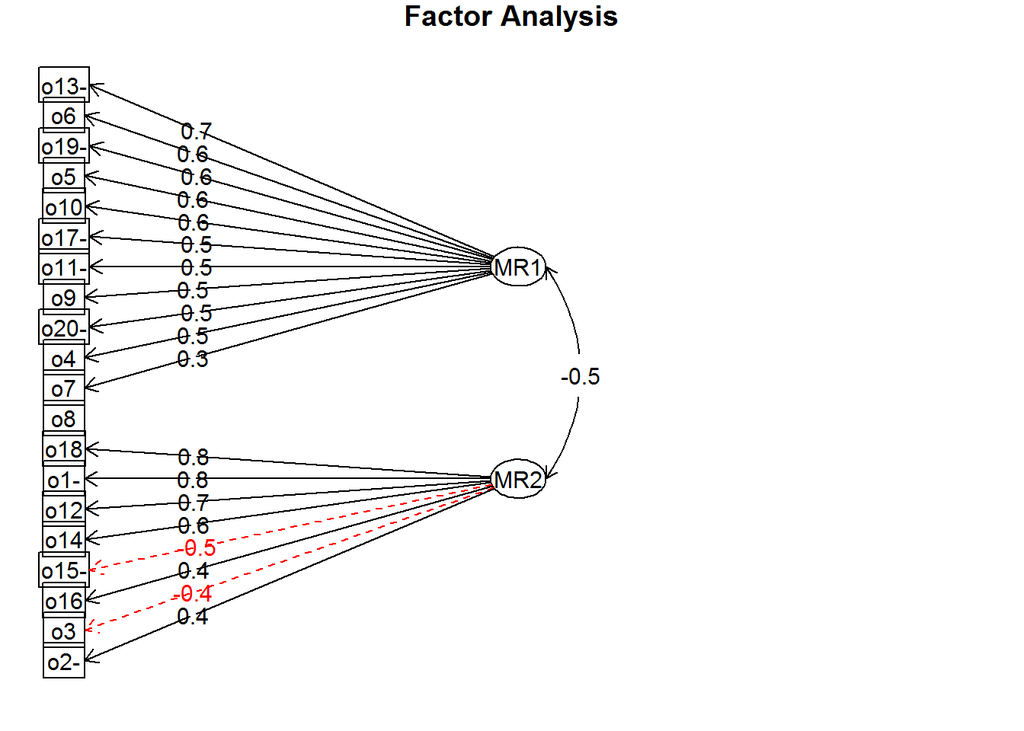

```r
fa.diagram(efafit2)
```

```r
efafit2$loadings
```

```
##
## Loadings:
##      MR1    MR2
## o1-          0.779
## o2-  -0.226  0.409
## o3   -0.291 -0.411
## o4    0.457  0.113
## o5    0.634
## o6    0.641
## o7    0.320
## o8    0.264 -0.263
## o9    0.509 -0.195
## o10   0.554 -0.144
## o11-  0.526 -0.375
## o12  -0.166  0.694
## o13-  0.653  0.110
## o14  -0.254  0.630
## o15- -0.372 -0.486
## o16  -0.352  0.442
## o17-  0.544 -0.151
## o18          0.783
## o19-  0.635
## o20-  0.493 -0.236
##
##                  MR1   MR2
## SS loadings    3.904 3.260
## Proportion Var 0.195 0.163
## Cumulative Var 0.195 0.358
```

#### As we see here that there are a great distortion in the loading with a huge drop in CFI

#### so we will back to 3 factor model

#### The following codes for reporting in tables

```r
fa.load<-matrix(efafit$loadings,ncol = 3,dimnames=list(c(paste0("q",1:20)),c("F1","F2","F3"))
)

fa.var<-matrix(efafit$Vaccounted,ncol = 3,dimnames = list(c("SS loading","Prop var","Cum var","Prop explain","Cum Prop"),c(paste0("MR",1:3))))

fa.cor<-matrix(efafit$score.cor,ncol = 3,dimnames = list(c(paste0("MR",1:3)),c(paste0("MR",1:3))))

efa.fit<-data.frame(fitm)

#Tables
kable(fa.var,format = "markdown",align = "c",digits = 3,caption = "Table1 : Variance Explanation for factors")
```

|  | MR1 | MR2 | MR3 |
| --- | --- | --- | --- |
| SS loading | 4.006 | 3.579 | 1.559 |
| Prop var | 0.200 | 0.179 | 0.078 |
| Cum var | 0.200 | 0.379 | 0.457 |
| Prop explain | 0.438 | 0.391 | 0.170 |
| Cum Prop | 0.438 | 0.830 | 1.000 |

```r
kable(fa.cor,format = "markdown",align = "c",digits = 3,caption = "Table2: the correlation between factors")
```

|  | MR1 | MR2 | MR3 |
| --- | --- | --- | --- |
| MR1 | 1.000 | -0.577 | 0.007 |
| MR2 | -0.577 | 1.000 | -0.117 |
| MR3 | 0.007 | -0.117 | 1.000 |

```r
kable(fa.load,format = "markdown",align = "c",digits = 3,caption = "Table3: Item Factor Loading")
```

|  | F1 | F2 | F3 |
| --- | --- | --- | --- |
| q1 | 0.126 | 0.882 | -0.015 |
| q2 | -0.117 | 0.523 | 0.104 |
| q3 | 0.065 | 0.056 | 0.828 |
| q4 | 0.427 | 0.069 | -0.086 |
| q5 | 0.681 | -0.010 | 0.027 |
| q6 | 0.653 | 0.079 | -0.049 |
| q7 | 0.307 | -0.086 | -0.043 |
| q8 | 0.358 | -0.139 | 0.174 |
| q9 | 0.639 | -0.042 | 0.185 |
| q10 | 0.539 | -0.157 | -0.026 |
| q11 | 0.527 | -0.356 | 0.047 |
| q12 | -0.039 | 0.816 | 0.042 |
| q13 | 0.658 | 0.107 | -0.043 |
| q14 | -0.174 | 0.694 | 0.004 |
| q15 | -0.046 | -0.047 | 0.832 |
| q16 | -0.234 | 0.566 | 0.112 |
| q17 | 0.519 | -0.176 | -0.039 |
| q18 | 0.023 | 0.652 | -0.244 |
| q19 | 0.642 | 0.083 | -0.036 |
| q20 | 0.443 | -0.285 | -0.060 |

```r
kable(efa.fit,format = "markdown",align = "c",digits = 3,caption = "Table4: Fit measures")
```

|  | fitm |
| --- | --- |
| RMS | 0.067 |
| RMSEA.RMSEA | 0.093 |
| RMSEA.lower | 0.062 |
| RMSEA.upper | 0.101 |
| RMSEA.confidence | 0.900 |
| TLI | 0.818 |
| CFI | 0.876 |

Finally lets Test the reliability of Each Factor by Alpha method

```r
#specifying the idx
f.idx<-list()
f.idx$f3<-c(5,13,6,19,9,10,11,17,20,4,8,7)
f.idx$f1<-c(1,12,14,18,16,2)
f.idx$f2<-c(15,3)
print(f.idx)
```

```
## $f3
##  [1]  5 13  6 19  9 10 11 17 20  4  8  7
##
## $f1
## [1]  1 12 14 18 16  2
##
## $f2
## [1] 15  3
```

```r
alpha(efadf[,f.idx$f1])$total #1st factor
```

```
##  raw_alpha std.alpha   G6(smc) average_r      S/N        ase     mean
##  0.8657526 0.8647266 0.8566808 0.5158337 6.392435 0.02040098 2.477193
##         sd  median_r
##  0.8964108 0.4978839
```

```r
alpha(efadf[,f.idx$f2])$total #2nd factor
```

```
##  raw_alpha std.alpha   G6(smc) average_r      S/N        ase     mean
##  0.8088697 0.8089486 0.6791887 0.6791887 4.234195 0.03920718 2.894737
##         sd  median_r
##  0.9534225 0.6791887
```

```r
alpha(efadf[,f.idx$f3])$total #3rd factor
```

```
##  raw_alpha std.alpha   G6(smc) average_r      S/N        ase     mean
##  0.8498509 0.8534846 0.8729874 0.3267965 5.825219 0.02229869 3.745614
##         sd  median_r
##  0.5937978 0.3188863
```

#### Here we see that all alpha for all factors are above .80 , and it is a good indicator for the reliability of each factor